# UgaldePascual_gradient_boost.rmd

Axela Keeza T. Ugalde; Javi A. Pascual

2026-07-20

# Activity 14 - Ensemble Learning: Gradient Boosting

## Definitions

**Disclaimer**: The content of this page were the output from Gemini AI.  
**Gradient Boosting**

It is an ensemble machine learning technique used for both regression and classification. It builds a strong predictive model by sequentially training a series of *“weak learners”* (typically shallow decision trees, or “stumps”).  
Unlike methods that train trees independently, Gradient Boosting works step-by-step. Each new tree is trained to predict the **residuals** (the errors or the gradient of the loss function) of the combined ensemble of all previous trees. By minimizing a defined loss function via gradient descent in the prediction space, the ensemble progressively reduces its overall error.

**Comparison with Random Forest**

| Feature | Random Forest | Gradient Boosting |
| --- | --- | --- |
| Ensemble Philosophy | **Bagging** (Bootstrap Aggregating) | **Boosting** |
| Tree Generation | Trees are built in **parallel and are completely independent**. | Trees are **built sequentially**; each tree depends on the errors of the prior ones. |
| Tree Depth | Typically uses **deep, fully-grown trees** (low bias, high variance). | Typically uses **shallow trees or stumps**(high bias, low variance). |
| Error Reduction | Primarily reduces **variance** by averaging un-correlated, deep trees. | Primarily reduces **bias** by sequentially correcting systematic errors. |
| Overfitting Risk | **Low.** Adding more trees does not cause overfitting; it just stabilizes the error. | **Moderate to High.** If the number of trees is too large, it can overfit the noise in the residuals. |
| Hyperparameters | **Fewer parameters** to tune (mostly number of trees and variables per split). | **Highly sensitive to hyperparameters** (learning rate, number of trees, tree depth). |

## Implementation Types

**Disclaimer**: The content of this page were the output from Gemini AI.  
**Different implementation types of Gradient Boosting**  
Depending on the underlying loss function, data structure, and optimization goals, Gradient Boosting can be implemented in several ways:

**1. Gradient Boosted Regression Trees (Continuous Data)**

- **Target Variable:** Continuous numerical values (e.g., housing prices, temperature).
- The classic implementation designed for continuous target variables. It typically optimizes the Mean Squared Error (MSE or $L_2$ loss) or Mean Absolute Error (MAE or $L_1$ loss). Each sequential tree is fit directly to the pseudo-residuals of the previous predictions.

**2. Gradient Boosted Classification Trees (Categorical/Discrete Data)**

- **Target Variable:** Binary (Yes/No, 0/1) or Multiclass labels (Red/Blue/Green).
- Used for binary or multiclass categorical targets. Instead of directly predicting classes, the trees predict log-odds (for binary classification) or class probabilities using a softmax-like objective, optimizing Bernoulli or Multinomial negative log-likelihood.

## Manual Implementation

**Disclaimer**: This code was made with Gemini AI.

```r
# Using the data from Activity 13
my_data <- read.csv("call_data_12October2025.csv")

# Clean and remove Remove first column
clean_data <- my_data[complete.cases(my_data), ]
frog_data <- clean_data[, -1]

# Force to character
frog_data$Species <- as.character(frog_data$Species)

# Select 2 most abundant species
top_species <- names(sort(table(frog_data$Species), decreasing = TRUE))[1:2]
binary_data <- frog_data[frog_data$Species %in% top_species, ]

# Assign to binary
y <- ifelse(binary_data$Species == top_species[1], 1, 0)

# Numeric measurements as Predictors
numeric_cols <- names(binary_data)[sapply(binary_data, is.numeric)]
X_mat <- binary_data[, numeric_cols]
n <- length(y)

# Vector to track SSE reduction
importance_scores <- numeric(length(numeric_cols))
names(importance_scores) <- numeric_cols

# Decision Stump function - find the single best split for current errors
fit_multi_stump <- function(X_matrix, residuals) {
  best_sse <- Inf
  best_feat <- NA
  best_split <- NA
  best_left_val <- NA
  best_right_val <- NA
  best_drop <- 0

# Calculate baseline error before splitting
  base_sse <- sum((residuals - mean(residuals))^2)

# Loop to calculate midpoints bet every consecutive value as potential split boundaries
  for (i in names(X_matrix)) {
    x_vec <- X_matrix[[i]]
    candidates <- unique(sort(x_vec))
    if(length(candidates) > 1) {
      candidates <- (candidates[-1] + candidates[-length(candidates)]) / 2
    }

# Loop through the candidates
    for (j in candidates) {
      left_idx  <- x_vec <= j #if smaller than or equal to split point
      right_idx <- !left_idx  #if larger than split point

      left_val  <- if(sum(left_idx) > 0) mean(residuals[left_idx]) else 0
      right_val <- if(sum(right_idx) > 0) mean(residuals[right_idx]) else 0

# Sum up remaining squared errors on both sides
      sse <- sum((residuals[left_idx] - left_val)^2) + sum((residuals[right_idx] - right_val)^2)

# If this split yields a lower error than any tested split
      if (sse < best_sse) {
        best_sse <- sse
        best_feat <- i
        best_split <- j
        best_left_val <- left_val
        best_right_val <- right_val
        best_drop <- base_sse - sse
      }
    }
  }

# Return a list containing all details of the absolute best stump
  return(list(feature = best_feat,
              split = best_split,
              left_val = best_left_val,
              right_val = best_right_val,
              sse_drop = best_drop))
}

# Classification Gradient Boosting Loop
M <- 30
learning_rate <- 0.1

p_init <- mean(y)
f_current <- rep(log(p_init / (1 - p_init)), n)

stumps_list <- list()

# Run the boosting loop sequentially 30 times
for (m in 1:M) {
  p_current <- 1 / (1 + exp(-f_current))
  residuals <- y - p_current

# Find the single best decision stump that fits these exact errors
  stump_m <- fit_multi_stump(X_mat, residuals)
  stumps_list[[m]] <- stump_m

# Accumulate the importance score based on how much SSE this split eliminated
  importance_scores[stump_m$feature] <- importance_scores[stump_m$feature] + stump_m$sse_drop

# Update ensemble predictions using the selected feature
  x_selected <- X_mat[[stump_m$feature]]
  pred_res <- ifelse(x_selected <= stump_m$split,
                     stump_m$left_val,
                     stump_m$right_val)
  f_current <- f_current + (learning_rate * pred_res)
}

# Sort
sorted_importance <- sort(importance_scores, decreasing = TRUE)
print(round(sorted_importance, 4))
```

```
##     Spectral_Centroid    Low_Peak_Frequency         Min_Amplitude
##               71.0355               20.0738               17.0157
##     Average_Frequency    Average_Wavelength         Max_Amplitude
##                0.0000                0.0000                0.0000
##             Rise_Time             Fall_Time         Call_Duration
##                0.0000                0.0000                0.0000
##        Delta_Power_dB    Dominant_Frequency   High_Peak_Frequency
##                0.0000                0.0000                0.0000
##             BW_Spread    Zero_Crossing_Rate Rate_of_Dominant_call
##                0.0000                0.0000                0.0000
```

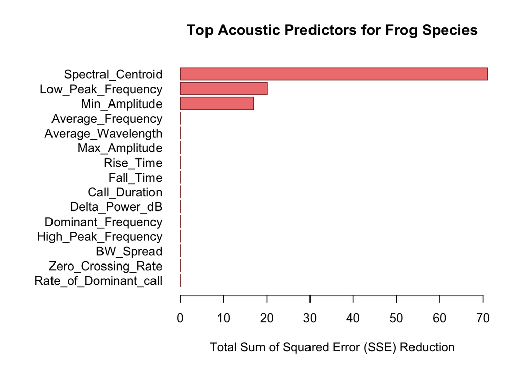

```r
# Graph
op <- par(mar = c(5, 12, 4, 2))

barplot(rev(sorted_importance),
        horiz = TRUE,
        las = 1,
        col = "lightcoral",
        border = "indianred4",
        main = "Top Acoustic Predictors for Frog Species",
        xlab = "Total Sum of Squared Error (SSE) Reduction")
```

```r
par(op)
```